# **Gráficos con ggplot2**

## 0.6 “geoms” adicionales

- `geom_smooth()` - añade las líneas de mejor ajuste (incluyendo CI)
- `geom_boxplot()` - Distribución de frecuencias
- `geom_histogram()` & `geom_freqpoly()` - distribuciones de frecuencia
- `geom_bar()` - distribución de frecuencias de variables categóricas
- `geom_path()` & `geom_line()` - añade líneas a los gráficos de dispersión

### 0.6.1 geom_smooth()

Las líneas de regresión de mejor ajuste pueden añadirse con `geom_smooth()`:

**Código**

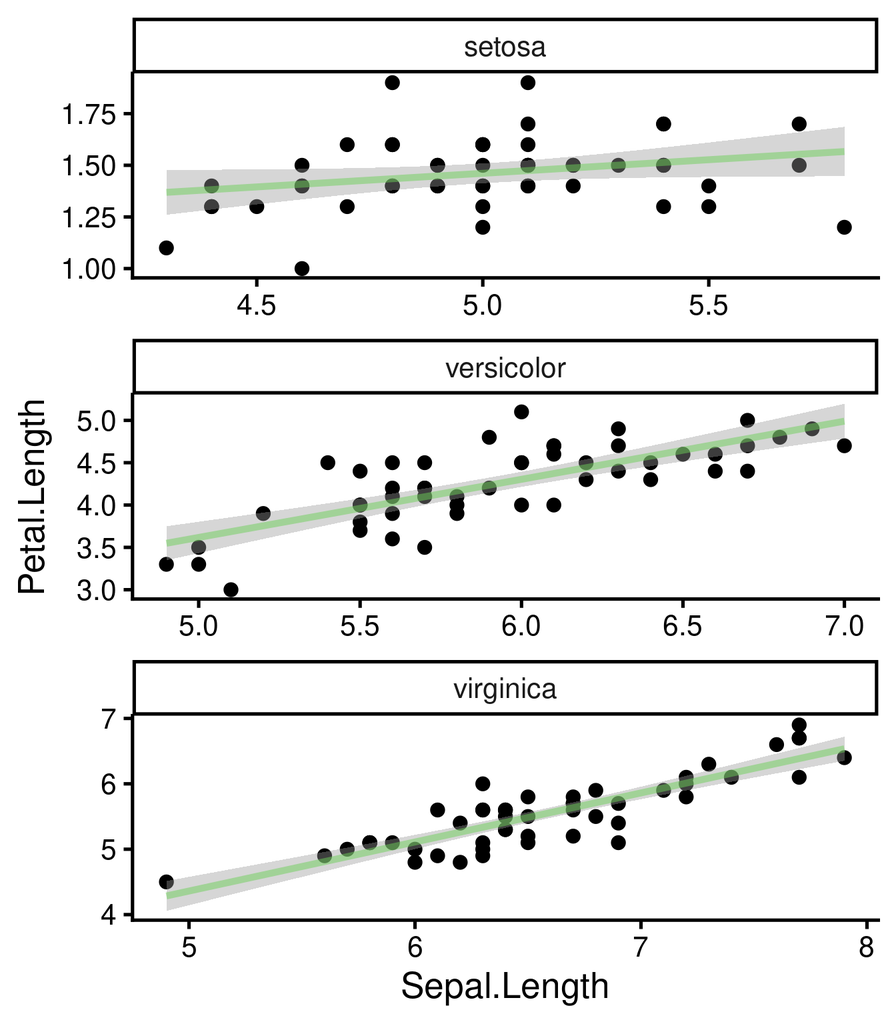

```r
# con CI
ggplot(iris, aes(Sepal.Length, Petal.Length)) +
  geom_point() +
  geom_smooth(method = "lm") +
  facet_wrap(~Species, scales = "free", nrow = 3)
```

**Código**

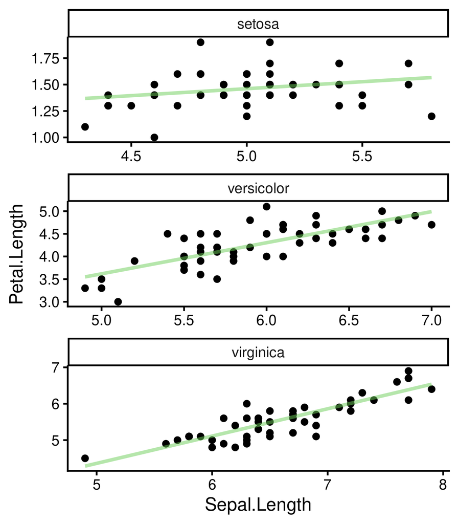

```r
# sin CI
ggplot(iris, aes(Sepal.Length, Petal.Length)) +
  geom_point() +
  geom_smooth(method = "lm", se = FALSE) +
  facet_wrap(~Species, scales = "free", nrow = 3)
```

Ejercicio 2

Utilizando el conjunto de datos de ejemplo “msleep”:

2.1 Crear un gráfico de dispersión de peso corporal (“bodywt”) frente a peso cerebral (“brainwt”)

2.2 Añadir orden (“order”) como estética del color

2.3 Añadir un componente “faceta” para dividir los gráficos por orden utilizando escalas libres

2.4 Elimine los órdenes con menos de 4 especies en el conjunto de datos y haga un gráfico similar al 2.3

2.5 Añadir una línea de mejor ajuste a cada gráfico del panel

### 0.6.2 Boxplots

De nuevo, sólo se necesita un nuevo componente “geom” para crear un boxplot:

**Código**

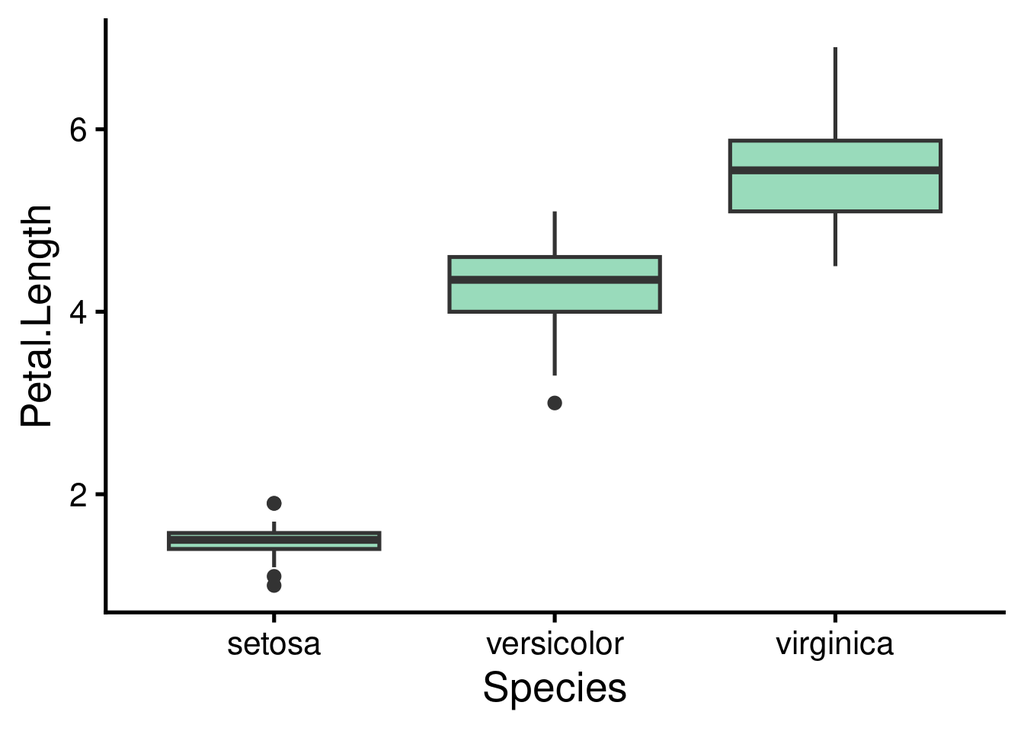

```r
ggplot(iris, aes(Species, Petal.Length)) +
  geom_boxplot()
```

Una alternativa interesante son los gráficos de violines:

**Código**

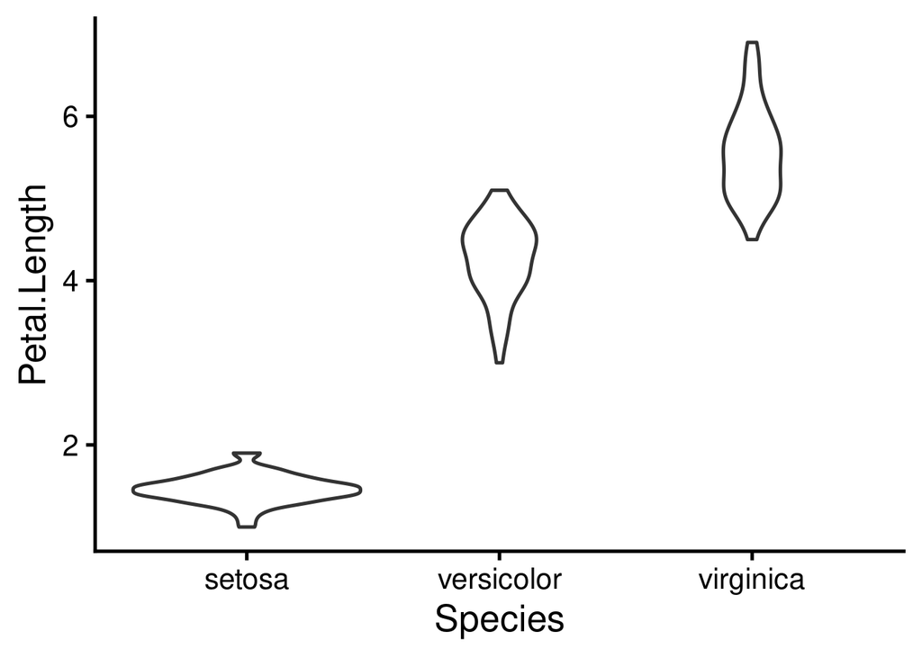

```r
ggplot(iris, aes(Species, Petal.Length)) +
  geom_violin()
```

### 0.6.3 Histogramas

Lo mismo ocurre con los histrogramas y los gráficos de frecuencias:

**Código**

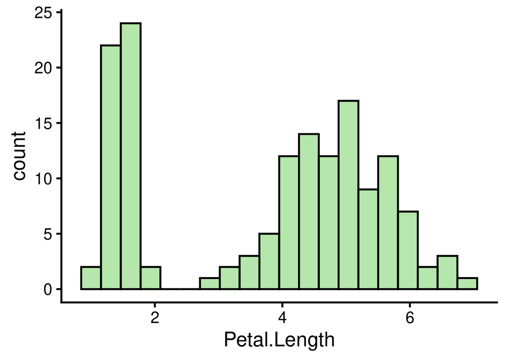

```r
ggplot(iris, aes(Petal.Length)) +
  geom_histogram()
```

**Código**

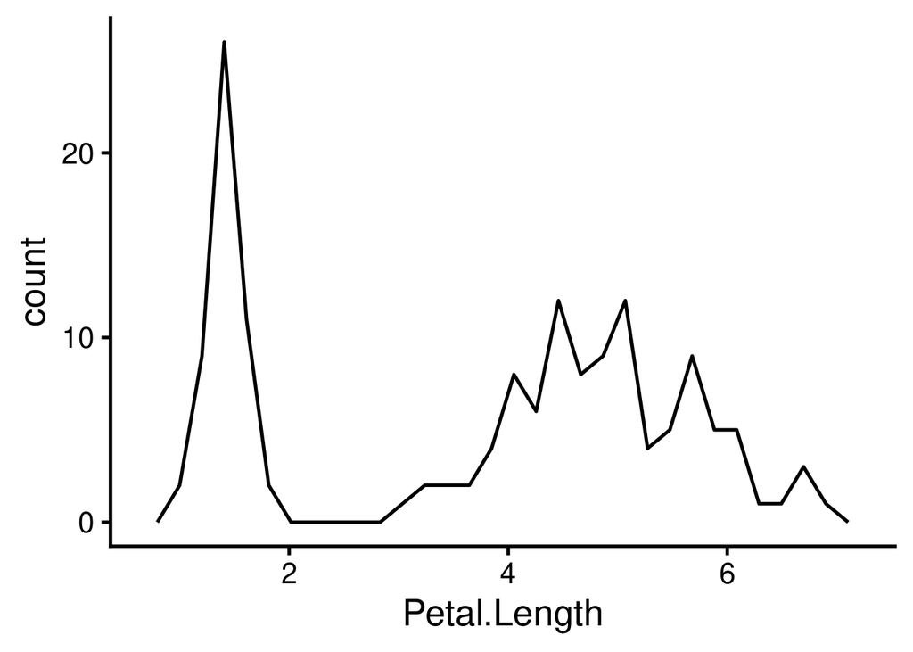

```r
ggplot(iris, aes(Petal.Length)) +
  geom_freqpoly()
```

**Código**

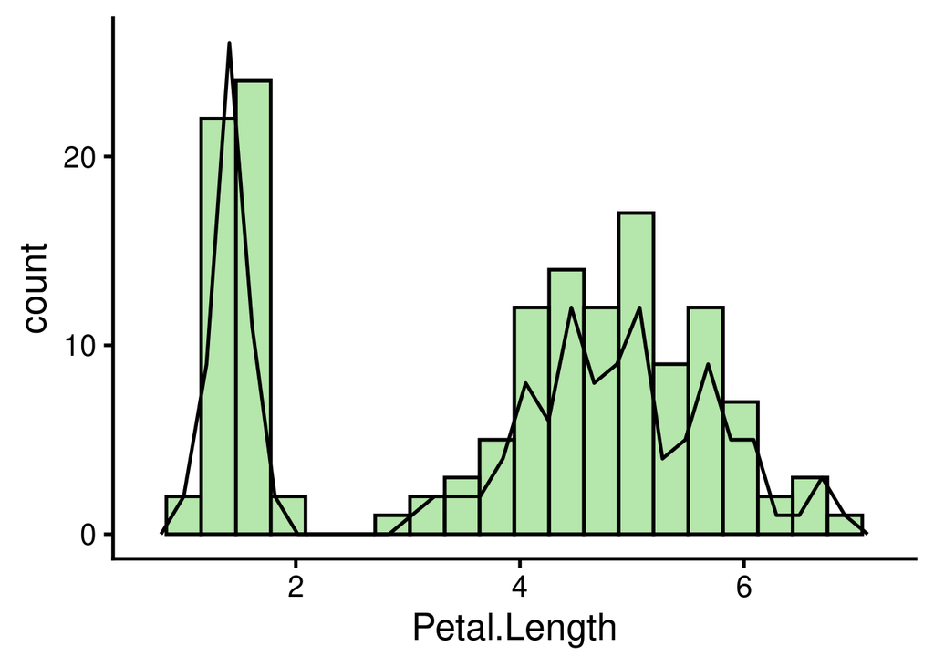

```r
ggplot(iris, aes(Petal.Length)) +
  geom_histogram() +
  geom_freqpoly()
```

Podemos controlar la anchura de las barras:

**Código**

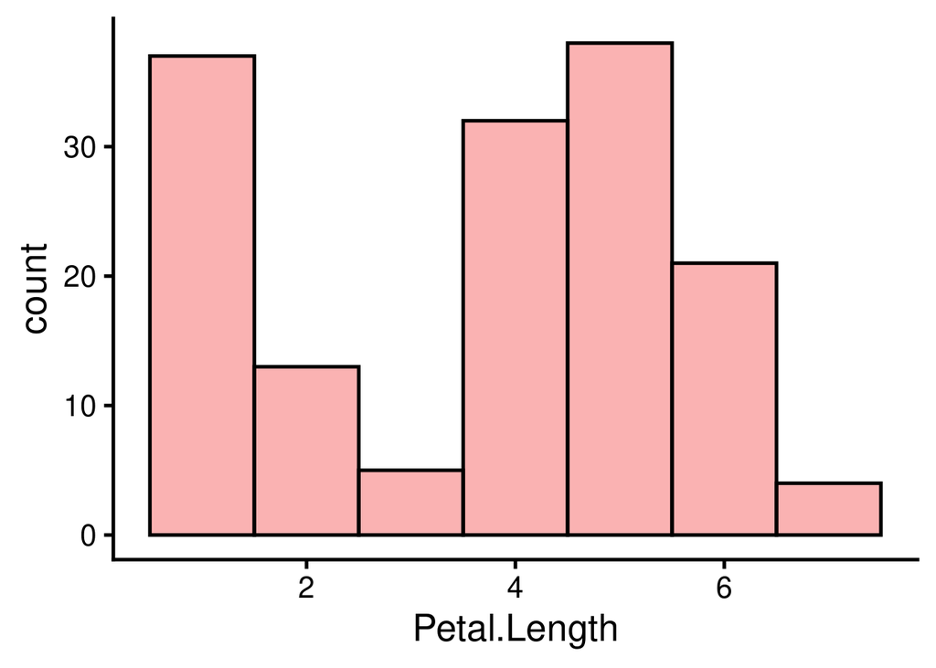

```r
ggplot(iris, aes(Petal.Length)) +
  geom_histogram(binwidth = 1, fill = adjustcolor("red2", alpha.f = 0.3))
```

Y compara la distribución de los distintos grupos dentro del mismo histograma:

**Código**

[figure not shown]

```r
ggplot(iris, aes(Petal.Length, fill = Species)) +
  geom_histogram(binwidth = 0.4)
```

### 0.6.4 Gráfico de barras

Muestran la distribución de variables discretas (categóricas):

**Código**

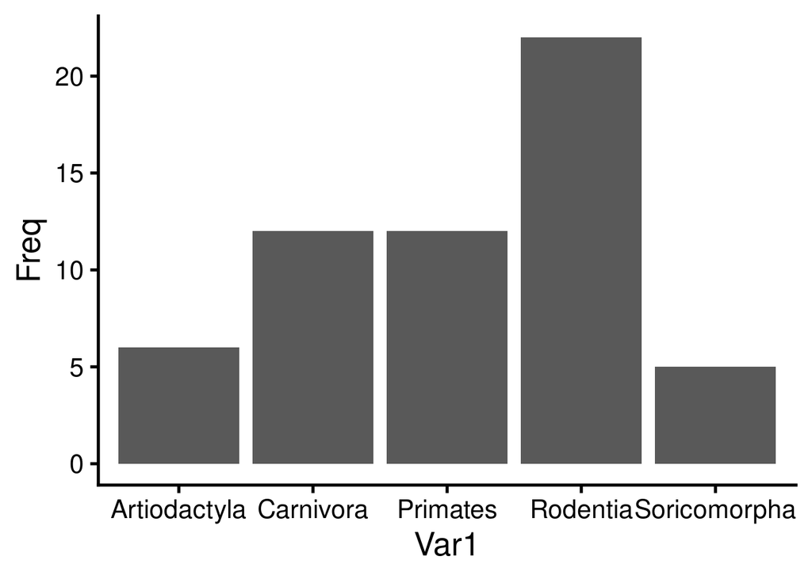

```r
tab <- table(msleep$order)

df <-
  as.data.frame(table(msleep$order[msleep$order %in% names(tab)[tab > 3]]))

ggplot(df, aes(Var1, Freq)) +
  geom_bar(stat = "identity")
```

## 0.7 Personalización de ggplots

Además de las funciones básicas (por ejemplo, componentes) descritas anteriormente, ggplot tiene muchas otras herramientas (tanto argumentos como funciones adicionales) para personalizar aún más los gráficos. Prácticamente todo se puede modificar. Aquí vemos algunas de las herramientas más comunes.

### 0.7.1 Temas

ggplot2 viene con algunos temas por defecto que se pueden aplicar fácilmente para modificar el aspecto de nuestros gráficos:

**Código**

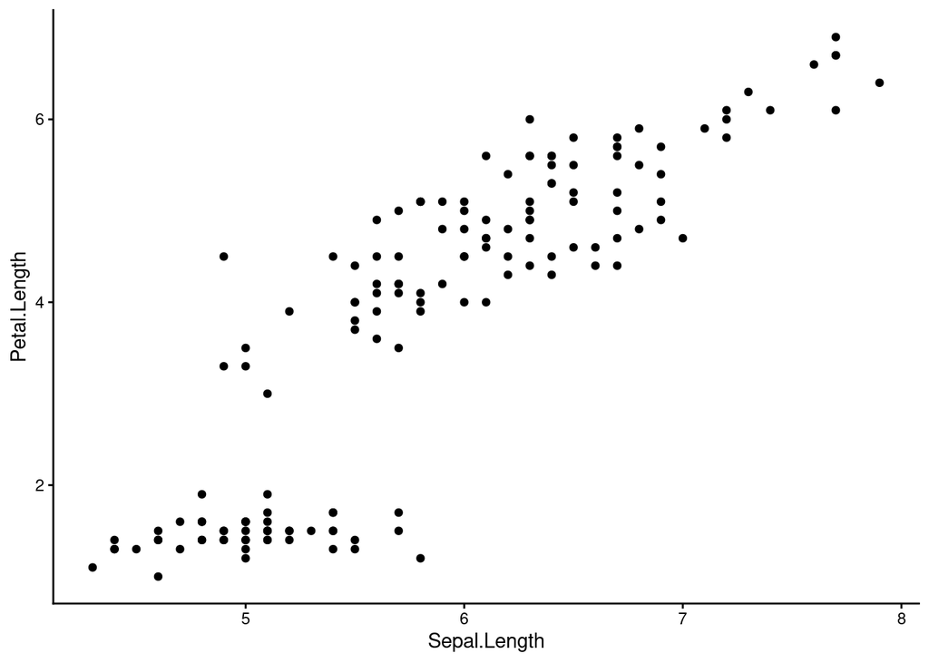

```r
p <- ggplot(iris, aes(Sepal.Length, Petal.Length)) +
  geom_point()

p + theme_classic()
```

**Código**

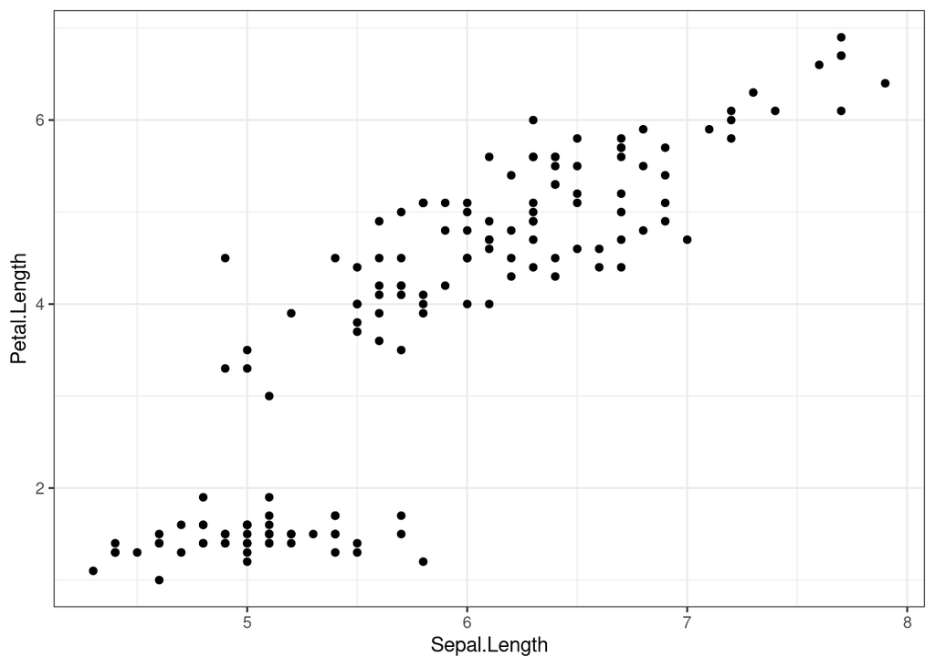

```r
p + theme_bw()
```

**Código**

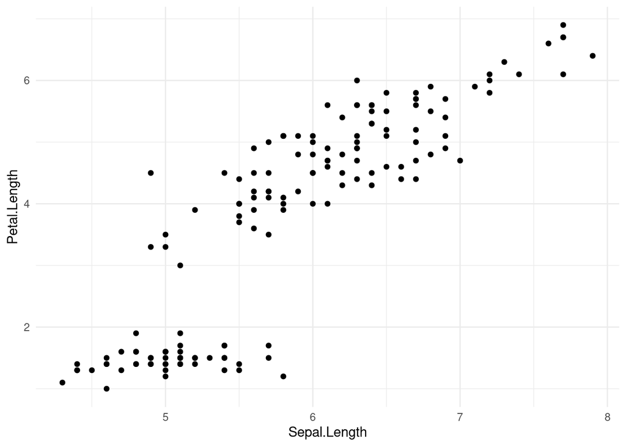

```r
p + theme_minimal()
```

La mayoría de los temas difieren en el uso de cuadrículas, líneas de borde y patrones de etiquetado de ejes.

### 0.7.2 Personalización de ejes

Los límites de los ejes pueden modificarse como sigue:

**Código**

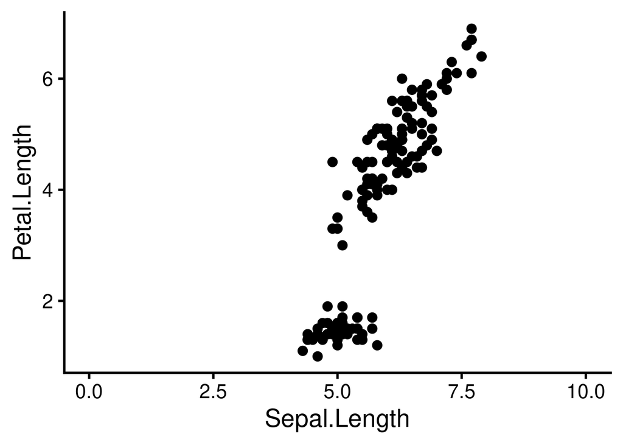

```r
ggplot(iris, aes(Sepal.Length, Petal.Length)) +
  geom_point() +
  xlim(c(0, 10))
```

**Código**

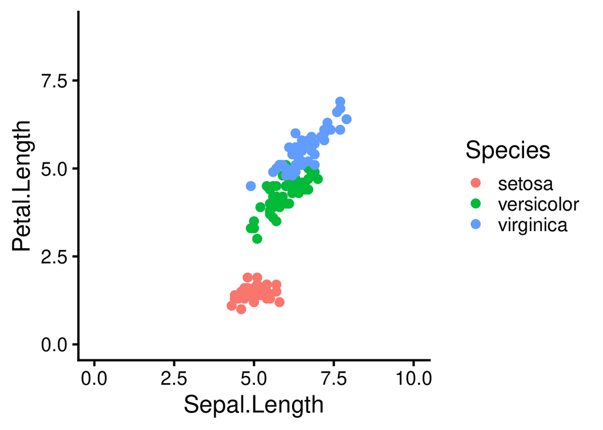

```r
ggplot(iris, aes(Sepal.Length, Petal.Length, col = Species)) +
  geom_point() +
  xlim(c(0, 10)) +
  ylim(c(0, 9))
```

Los ejes también pueden transformarse:

**Código**

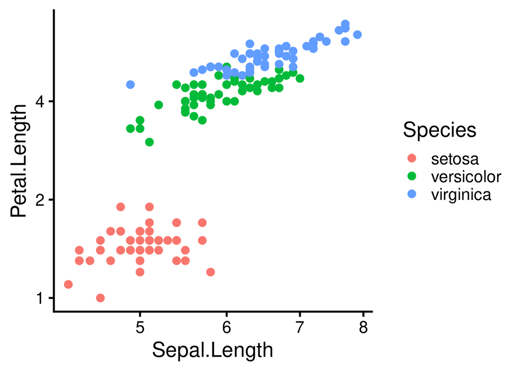

```r
ggplot(iris, aes(Sepal.Length, Petal.Length, col = Species)) +
  geom_point() +
  scale_x_continuous(trans = "log") +
  scale_y_continuous(trans = "log2")
```

o invertidos:

**Código**

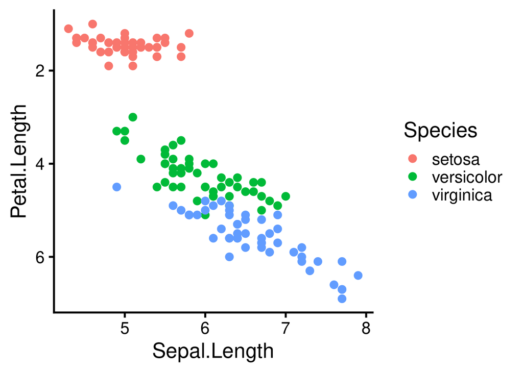

```r
ggplot(iris, aes(Sepal.Length, Petal.Length, col = Species)) +
  geom_point() +
  scale_y_reverse()
```